# 学习笔记-Rstudio可视化编辑器之技术写作

Rstudio - Visual Editor

quarto

rstudio

学习笔记

理工男逃不开的技术写作，就从这里开始

作者

ZHU QUANMING

日期

2024/06/22,第25周

Keywords

Quarto, Rstudio, Tips, Notes

## 如何写公式

技术写作背后的原理和支持技术其实就是`LaTex`, `Pandoc` `Markdown`。 在`Quarto 1.4`中引入了`Typst`, 号称比`LaTex`更好使用，希望可以早点用上去。

### 内联的公式

举例: $\sqrt x=26$ 的解就是$x=676$

写这个公式的时候要注意：

1. sqrt后是空格后再写x, 而不是`\sqrt(x`, 那样的话就变成了 $\sqrt(x)$
2. 其实，在输入美元符号$的时候，连续输入三个$，这样才会进入公式输入模式。如果只输入一个$或两个美元符号，然后在中间加入符号，它不会变成类的公司。

## 正式公式

为什么写不出教程里红色的$$的样子？把 公式latex代码直接显示处理啊反而有点难啊.。 TODO, 即使插入raw tex block (上面一个公式其实我是希望显示源代码的啊)

2024-06-23 如果只是要显示源代码，不运算，请在将代码语言标记从`{lang}` 改为 `{=lang}` 即可

```r
install.packages("test")
```

## 交叉索引

因为每个需要交叉索引的实体(如图片、公式、表格或者其中的某一段文字)，建立一个标签，给出一个唯一的标记，这样就可以在文章中随便引用了。

`![Elephant](crossref-figure.png){#fig-elephant fig-alt="Altnative text" fig-align="center"}`

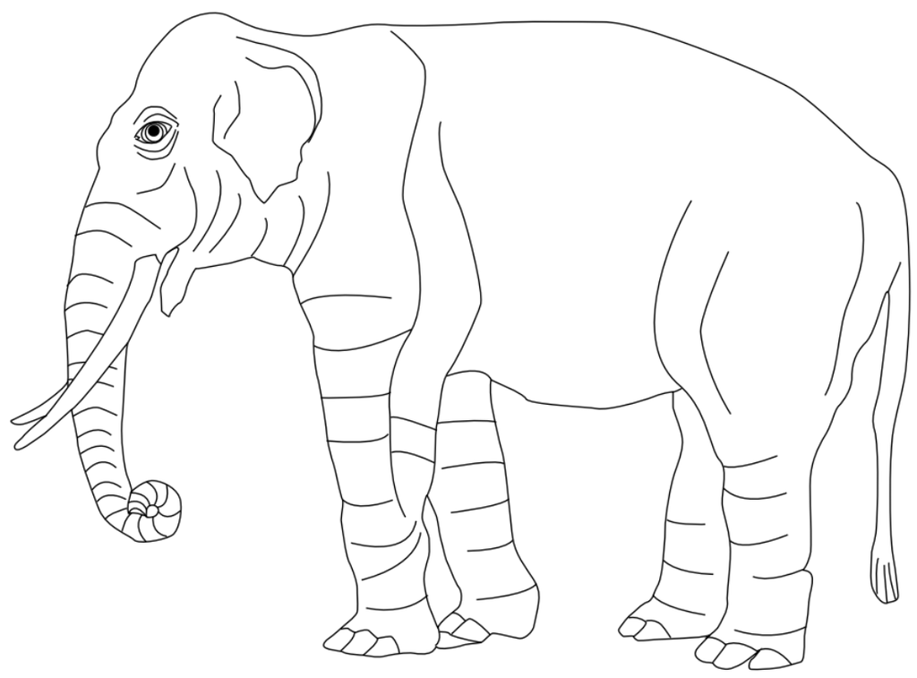

Figure 1: Elephant

在这种情况下，我们只要在其他地方引用`@fig-elephant`即可连接到这个实体了。

See Figure 1 for details

## 两种编辑模式

不知道为什么``的使用不知道如何删除，有的时候你会发现，输入错误了，但是不知道如何在可视化编辑器里修改，只能切换到源代码模式里进行。所 以两种方式是相辅相成的，需要结合使用才好。

Here’s some raw inline HTML: html

实际上你需要在两种模式中来回的切换，尽量使用每一种模式中最熟悉的部分，这样也可以检查文件在两种模式中都显示正常，因为在某些时候你的合作者有的喜欢可视化模式，女的喜欢，源代码模式，无论哪种模式，最终的结果都要确保其正确。

## bugs

`CMD+S` 不能保存文件，，选择关闭文件提醒保存垫子保存后仍然无法保存。重 新关闭后打开，恢复了，看来稳定性还是有些问题。